# ПРЕДИКТИВНАЯ СИСТЕМА ОЦЕНКИ КАЧЕСТВА ГОТОВОЙ ПРОДУКЦИИ НА ОСНОВЕ РЕЦЕПТУРЫ ШИХТЫ

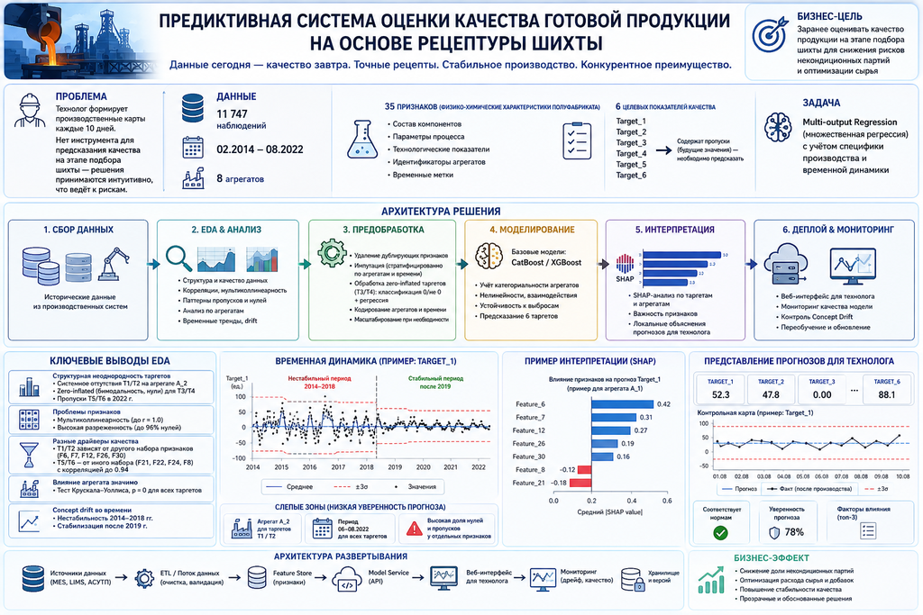

## Введение

В рамках данного проекта решается критически важная бизнес-задача металлургического производства: **оптимизация процесса составления производственных карт, которые технолог формирует каждые 10 дней**. Основная проблема заключается в необходимости заранее оценивать качество готовой продукции на этапе подбора состава компонентов (шихты), чтобы гарантировать строгое соответствие нормативам потребителей. Внедрение инструмента предиктивной аналитики позволит специалисту перейти от интуитивного подбора рецептов к принятию решений, подкрепленных данными, что снизит риски выпуска некондиционных партий и оптимизирует использование сырья.

С точки зрения Data Science, задача формулируется как **Multi-output Regression** (множественная регрессия). В основе решения лежит исторический массив из более чем 11 700 наблюдений, содержащий 35 физико-химических характеристик полуфабриката, временные метки и идентификаторы производственных агрегатов. **Целевыми переменными** выступают 6 ключевых метрик качества готового продукта. Специфика датасета заключается в том, что целевые показатели **содержат пропуски**, которые представляют собой будущие значения (отложенную тестовую выборку) — именно для них необходимо построить точный прогноз, опираясь исключительно на известные параметры сырья.

Ключевым требованием к решению является не только математическая точность, но и полная прозрачность алгоритма для конечного пользователя. Модель должна быть **интерпретируемой**: технолог должен понимать, какие именно характеристики шихты сильнее всего влияют на целевые показатели, а также видеть доступные визуализации прогнозов. Помимо обучения алгоритма, проект охватывает **полный жизненный цикл ML-решения**: от глубокого исследования данных (**EDA**) с учетом производственной специфики до предложения архитектуры развертывания модели на серверах и разработки стратегии мониторинга её деградации (**Concept Drift**) во времени.

Фундаментом для построения надежной модели служит комплексный **EDA**, спроектированный как аналитический отчет для кросс-функциональной аудитории (**Data Scientist, технолог, руководитель R&D**). Такой подход позволяет не просто выявить статистические корреляции, но и понять природу производственного процесса, учесть разницу между агрегатами, очистить данные от аномалий измерений и заложить корректную стратегию временной валидации, что в итоге гарантирует высокую бизнес-ценность и реальную внедряемость итогового продукта.

# 🗺️ Навигация по ноутбуку

- ПРЕДИКТИВНАЯ СИСТЕМА ОЦЕНКИ КАЧЕСТВА ГОТОВОЙ ПРОДУКЦИИ
  - Введение
- Импорт библиотек и настройка окружения
- Загрузка данных
- Общая информация о данных
- Определение списков признаков
- Анализ пропусков
  - Пропуски только по Target
  - Проверка нулей как скрытых пропусков
  - Анализ природы пропусков
- Анализ целевых переменных
  - Корреляция Target
  - Feature -> Target
  - Мультиколлинеарность
- Zero inflation (избыток нулей / раздувание нулей)
- Анализ выбросов
- Контрольные карты (Control Charts)
- Target по агрегатам
- Статистические различия между агрегатами
- Итоговый отчет
  - Итоговый вывод по результатам разведочного анализа данных (EDA)

# Импорт библиотек и настройка окружения

```python
import numpy as np
import pandas as pd
import matplotlib.pyplot as plt
import seaborn as sns
from scipy import stats
import missingno as msno
HAS_MISSINGNO = True

import warnings
warnings.filterwarnings("ignore")
```

```python
sns.set_theme(style="whitegrid", context="notebook")
plt.rcParams["figure.figsize"] = (12, 6)
plt.rcParams["axes.titlesize"] = 14
plt.rcParams["axes.labelsize"] = 12

pd.set_option("display.max_columns", None)
pd.set_option("display.width", 200)
pd.set_option("display.float_format", lambda x: f"{x:.5f}")
```

# Загрузка данных

```python
FILE_PATH = "Dataset_Тестовое_Задание_DS.xlsb"
df = pd.read_excel(FILE_PATH, engine="pyxlsb")
```

```python
# Конвертация Excel Serial Date
df["DATE"] = pd.to_datetime(df["DATE"], origin="1899-12-30", unit="D")
df = df.sort_values("DATE").reset_index(drop=True)
```

# Общая информация о данных

```python
print("\nРазмер датасета:", df.shape)
```

```
Размер датасета: (11747, 44)
```

```python
# Первые строки
df.head(3)
```

|  | INDEX | DATE | Aggregate | Target_1 | Target_2 | Target_3 | Target_4 | Target_5 | Target_6 | Feature_1 | Feature_2 | Feature_3 | Feature_4 | Feature_5 | Feature_6 | Feature_7 | Feature_8 | Feature_9 | Feature_10 | Feature_11 | Feature_12 | Feature_13 | Feature_14 | Feature_15 | Feature_16 | Feature_17 | Feature_18 | Feature_19 | Feature_20 | … |
| --- | --- | --- | --- | --- | --- | --- | --- | --- | --- | --- | --- | --- | --- | --- | --- | --- | --- | --- | --- | --- | --- | --- | --- | --- | --- | --- | --- | --- | --- | --- |
| 0 | 6215 | 2014-02-15 | A_1 | 74.25975 | 0.59970 | 0.00000 | 0.00000 | 1.04403 | 0.00499 | 6.28190 | 2.55014 | 0.01184 | 40.78156 | 58.83455 | 25557.63230 | 6.04619 | 0.41435 | 0.00000 | 0.00000 | 0.00000 | 0.00000 | 0.17378 | 0.03735 | 0.00281 | 0.00130 | 0.04705 | 0.00036 | 2.93319 | 35.56311 | … |
| 1 | 6216 | 2014-02-16 | A_1 | 74.43245 | 0.58432 | 0.00000 | 0.00000 | 1.02355 | 0.00491 | 6.28143 | 2.55055 | 0.01183 | 40.08529 | 59.22162 | 25505.11831 | 6.13135 | 0.41388 | 0.00000 | 0.00000 | 0.00000 | 0.00000 | 0.17356 | 0.03730 | 0.00280 | 0.00130 | 0.04725 | 0.00036 | 2.93478 | 35.52270 | … |
| 2 | 6217 | 2014-02-17 | A_1 | 74.43245 | 0.56895 | 30.24351 | 4.01272 | 1.02355 | 0.00477 | 6.28977 | 2.55643 | 0.01183 | 39.92380 | 58.91197 | 25502.27985 | 6.04619 | 0.41486 | 0.00000 | 0.00000 | 0.00000 | 0.00000 | 0.17376 | 0.03734 | 0.00280 | 0.00130 | 0.04714 | 0.00036 | 2.93866 | 35.58357 | … |

```python
print("\nОбщая информация:")
df.info()
```

```
Общая информация:
<class 'pandas.DataFrame'>
RangeIndex: 11747 entries, 0 to 11746
Data columns (total 44 columns):
 #   Column      Non-Null Count  Dtype
---  ------      --------------  -----
 0   INDEX       11747 non-null  int64
 1   DATE        11747 non-null  datetime64[s]
 2   Aggregate   11747 non-null  str
 3   Target_1    10349 non-null  float64
 4   Target_2    10372 non-null  float64
 5   Target_3    8008 non-null   float64
 6   Target_4    8007 non-null   float64
 7   Target_5    10707 non-null  float64
 8   Target_6    10710 non-null  float64
```

[output cut: 37 more lines]

```python
print("\nОписание числовых признаков:")
display(df.describe(include="all").T)
```

```
Описание числовых признаков:
```

|  | count | unique | top | freq | mean | min | 25% | 50% | 75% | max | std |
| --- | --- | --- | --- | --- | --- | --- | --- | --- | --- | --- | --- |
| INDEX | 11747.00000 | NaN | NaN | NaN | 6014.18958 | 0.00000 | 2990.50000 | 5988.00000 | 9034.50000 | 12225.00000 | 3486.99458 |
| DATE | 11747 | NaN | NaN | NaN | 2019-04-11 01:43:42 | 2014-02-15 00:00:00 | 2018-03-15 00:00:00 | 2019-04-01 00:00:00 | 2020-11-28 00:00:00 | 2022-08-22 00:00:00 | NaN |
| Aggregate | 11747 | 8 | A_3 | 2761 | NaN | NaN | NaN | NaN | NaN | NaN | NaN |
| Target_1 | 10349.00000 | NaN | NaN | NaN | 74.53505 | 0.00000 | 73.56896 | 74.60515 | 75.81403 | 79.78606 | 4.81934 |
| Target_2 | 10372.00000 | NaN | NaN | NaN | 0.59182 | 0.00000 | 0.56895 | 0.59970 | 0.61508 | 0.81498 | 0.05895 |
| Target_3 | 8008.00000 | NaN | NaN | NaN | 20.08659 | 0.00000 | 0.00000 | 27.63321 | 28.98337 | 34.38400 | 12.92625 |
| Target_4 | 8007.00000 | NaN | NaN | NaN | 2.97218 | 0.00000 | 0.00000 | 4.06461 | 4.47972 | 14.25209 | 2.10070 |
| Target_5 | 10707.00000 | NaN | NaN | NaN | 1.04829 | 0.00000 | 1.01332 | 1.04403 | 1.08497 | 2.03687 | 0.08315 |
| Target_6 | 10710.00000 | NaN | NaN | NaN | 0.00536 | 0.00000 | 0.00484 | 0.00543 | 0.00609 | 0.01291 | 0.00106 |
| Feature_1 | 11747.00000 | NaN | NaN | NaN | 5.92403 | 4.05323 | 5.76244 | 5.88666 | 6.03522 | 9.02188 | 0.30640 |
| Feature_2 | 11747.00000 | NaN | NaN | NaN | 2.54384 | 1.27595 | 2.45007 | 2.54083 | 2.63426 | 7.01775 | 0.22473 |
| Feature_3 | 11747.00000 | NaN | NaN | NaN | 0.01247 | 0.00916 | 0.01200 | 0.01235 | 0.01294 | 0.01764 | 0.00067 |
| Feature_4 | 11747.00000 | NaN | NaN | NaN | 42.26643 | 26.65518 | 41.09190 | 42.51934 | 43.53807 | 63.71239 | 2.39043 |
| Feature_5 | 11747.00000 | NaN | NaN | NaN | 59.92910 | 45.05488 | 58.09912 | 58.75714 | 61.23438 | 591.44209 | 6.33395 |
| Feature_6 | 11747.00000 | NaN | NaN | NaN | 24690.18391 | 14903.88523 | 24013.79670 | 24932.55837 | 25536.42329 | 66143.37021 | 1222.37842 |
| Feature_7 | 11747.00000 | NaN | NaN | NaN | 5.43555 | 0.87428 | 4.96564 | 5.59202 | 6.07222 | 23.39027 | 0.99490 |
| Feature_8 | 11747.00000 | NaN | NaN | NaN | 0.39083 | 0.00000 | 0.15996 | 0.40920 | 0.57386 | 2.18808 | 0.25536 |
| Feature_9 | 11747.00000 | NaN | NaN | NaN | 0.00023 | 0.00000 | 0.00000 | 0.00000 | 0.00000 | 0.00285 | 0.00067 |
| Feature_10 | 11747.00000 | NaN | NaN | NaN | 0.00588 | 0.00000 | 0.00000 | 0.00000 | 0.00000 | 0.06688 | 0.01715 |
| Feature_11 | 11747.00000 | NaN | NaN | NaN | 0.00327 | 0.00000 | 0.00000 | 0.00572 | 0.00572 | 0.00572 | 0.00283 |
| Feature_12 | 11747.00000 | NaN | NaN | NaN | 0.00039 | 0.00000 | 0.00000 | 0.00000 | 0.00000 | 0.00197 | 0.00078 |
| Feature_13 | 11747.00000 | NaN | NaN | NaN | 0.17989 | 0.08528 | 0.16947 | 0.18174 | 0.18886 | 0.37646 | 0.01495 |
| Feature_14 | 11747.00000 | NaN | NaN | NaN | 0.03994 | 0.01341 | 0.03762 | 0.04056 | 0.04240 | 0.08201 | 0.00341 |
| Feature_15 | 11747.00000 | NaN | NaN | NaN | 0.00231 | 0.00082 | 0.00212 | 0.00224 | 0.00243 | 0.00807 | 0.00033 |
| Feature_16 | 11747.00000 | NaN | NaN | NaN | 0.00114 | 0.00011 | 0.00105 | 0.00117 | 0.00123 | 0.00783 | 0.00017 |
| Feature_17 | 11747.00000 | NaN | NaN | NaN | 0.04230 | 0.01505 | 0.03948 | 0.04217 | 0.04458 | 0.25116 | 0.00614 |
| Feature_18 | 11747.00000 | NaN | NaN | NaN | 0.00059 | 0.00000 | 0.00053 | 0.00061 | 0.00069 | 0.00251 | 0.00014 |
| Feature_19 | 11747.00000 | NaN | NaN | NaN | 2.90688 | 0.00000 | 2.75720 | 2.93625 | 3.14873 | 5.58137 | 0.48681 |
| Feature_20 | 11747.00000 | NaN | NaN | NaN | 44.31042 | -16.64152 | 38.29708 | 43.40351 | 48.41068 | 370.10737 | 14.09938 |
| Feature_21 | 11747.00000 | NaN | NaN | NaN | 1.09832 | 0.61719 | 1.05709 | 1.09241 | 1.12454 | 2.22385 | 0.06629 |
| Feature_22 | 11747.00000 | NaN | NaN | NaN | 0.00931 | 0.00336 | 0.00853 | 0.00946 | 0.01048 | 0.02260 | 0.00166 |
| Feature_23 | 11747.00000 | NaN | NaN | NaN | 0.00324 | 0.00198 | 0.00309 | 0.00322 | 0.00336 | 0.00751 | 0.00030 |
| Feature_24 | 11747.00000 | NaN | NaN | NaN | 0.00157 | 0.00000 | 0.00118 | 0.00166 | 0.00202 | 0.00763 | 0.00074 |
| Feature_25 | 11747.00000 | NaN | NaN | NaN | 18.39340 | 1.33802 | 17.49762 | 18.21115 | 19.10635 | 30.37236 | 1.76339 |
| Feature_26 | 11747.00000 | NaN | NaN | NaN | 0.54146 | 0.50441 | 0.53951 | 0.54227 | 0.54403 | 0.61406 | 0.00377 |
| Feature_27 | 11747.00000 | NaN | NaN | NaN | 79.78119 | 49.83232 | 77.66743 | 79.61652 | 81.93751 | 137.86974 | 4.97598 |
| Feature_28 | 11747.00000 | NaN | NaN | NaN | 0.12122 | 0.00000 | 0.00000 | 0.00000 | 0.00000 | 3.48171 | 0.63460 |
| Feature_29 | 11747.00000 | NaN | NaN | NaN | 0.00037 | 0.00000 | 0.00000 | 0.00000 | 0.00000 | 0.00192 | 0.00076 |
| Feature_30 | 11747.00000 | NaN | NaN | NaN | 0.00000 | 0.00000 | 0.00000 | 0.00000 | 0.00000 | 0.00000 | 0.00000 |
| Feature_31 | 11747.00000 | NaN | NaN | NaN | 0.00000 | 0.00000 | 0.00000 | 0.00000 | 0.00000 | 0.00001 | 0.00000 |
| Feature_32 | 11747.00000 | NaN | NaN | NaN | 0.00003 | 0.00000 | 0.00000 | 0.00000 | 0.00007 | 0.00016 | 0.00004 |
| Feature_33 | 11747.00000 | NaN | NaN | NaN | 0.00000 | 0.00000 | 0.00000 | 0.00000 | 0.00000 | 0.00000 | 0.00000 |
| Feature_34 | 11747.00000 | NaN | NaN | NaN | 0.00000 | 0.00000 | 0.00000 | 0.00000 | 0.00000 | 0.00003 | 0.00000 |
| Feature_35 | 11747.00000 | NaN | NaN | NaN | 0.00011 | 0.00000 | 0.00005 | 0.00011 | 0.00015 | 0.00089 | 0.00008 |

# Определение списков признаков

```python
feature_cols = sorted([c for c in df.columns if c.startswith("Feature_")],
                      key=lambda x: int(x.split("_")[1]))
target_cols = sorted([c for c in df.columns if c.startswith("Target_")],
                     key=lambda x: int(x.split("_")[1]))
meta_cols = ["DATE", "Aggregate"]

print("\nКоличество признаков:", len(feature_cols))
print("Количество таргетов:", len(target_cols))
```

```
Количество признаков: 35
Количество таргетов: 6
```

**ВЫВОДЫ по общей структуре и качестве данных:**

Датасет содержит 11 747 наблюдений за период с февраля 2014 по август 2022 года, что представляет собой достаточную выборку для построения надежной регрессионной модели. Данные охватывают 8 производственных агрегатов (наиболее частый — A_3 с 2 761 записью), что указывает на необходимость учета агрегата как важного категориального признака или фактора стратификации при моделировании. Все признаки представлены в числовом формате (float64), а целевые переменные имеют разную степень заполненности: `Target_1`, `Target_2`, `Target_5` и `Target_6` заполнены примерно на 88-91%, тогда как `Target_3` и `Target_4` имеют значительные пропуски (~32% missing values), что потребует отдельной стратегии обработки пропущенных значений или возможного исключения этих таргетов из анализа, если пропуски не носят случайный характер.

.

# Анализ пропусков

```python
missing_table = pd.DataFrame({"Пропусков": df.isna().sum(), "%": df.isna().mean() * 100}).sort_values("%", ascending=False)
display(missing_table)
```

|  | Пропусков | % |
| --- | --- | --- |
| Target_4 | 3740 | 31.83792 |
| Target_3 | 3739 | 31.82940 |
| Target_1 | 1398 | 11.90091 |
| Target_2 | 1375 | 11.70512 |
| Target_5 | 1040 | 8.85332 |
| Target_6 | 1037 | 8.82779 |
| INDEX | 0 | 0.00000 |
| DATE | 0 | 0.00000 |
| Aggregate | 0 | 0.00000 |
| Feature_1 | 0 | 0.00000 |
| Feature_2 | 0 | 0.00000 |
| Feature_3 | 0 | 0.00000 |
| Feature_4 | 0 | 0.00000 |
| Feature_5 | 0 | 0.00000 |
| Feature_6 | 0 | 0.00000 |
| Feature_7 | 0 | 0.00000 |
| Feature_8 | 0 | 0.00000 |
| Feature_9 | 0 | 0.00000 |
| Feature_10 | 0 | 0.00000 |
| Feature_11 | 0 | 0.00000 |
| Feature_12 | 0 | 0.00000 |
| Feature_13 | 0 | 0.00000 |
| Feature_14 | 0 | 0.00000 |
| Feature_15 | 0 | 0.00000 |
| Feature_16 | 0 | 0.00000 |
| Feature_17 | 0 | 0.00000 |
| Feature_18 | 0 | 0.00000 |
| Feature_19 | 0 | 0.00000 |
| Feature_20 | 0 | 0.00000 |
| Feature_21 | 0 | 0.00000 |
| Feature_22 | 0 | 0.00000 |
| Feature_23 | 0 | 0.00000 |
| Feature_24 | 0 | 0.00000 |
| Feature_25 | 0 | 0.00000 |
| Feature_26 | 0 | 0.00000 |
| Feature_27 | 0 | 0.00000 |
| Feature_28 | 0 | 0.00000 |
| Feature_29 | 0 | 0.00000 |
| Feature_30 | 0 | 0.00000 |
| Feature_31 | 0 | 0.00000 |
| Feature_32 | 0 | 0.00000 |
| Feature_33 | 0 | 0.00000 |
| Feature_34 | 0 | 0.00000 |
| Feature_35 | 0 | 0.00000 |

## Пропуски только по Target

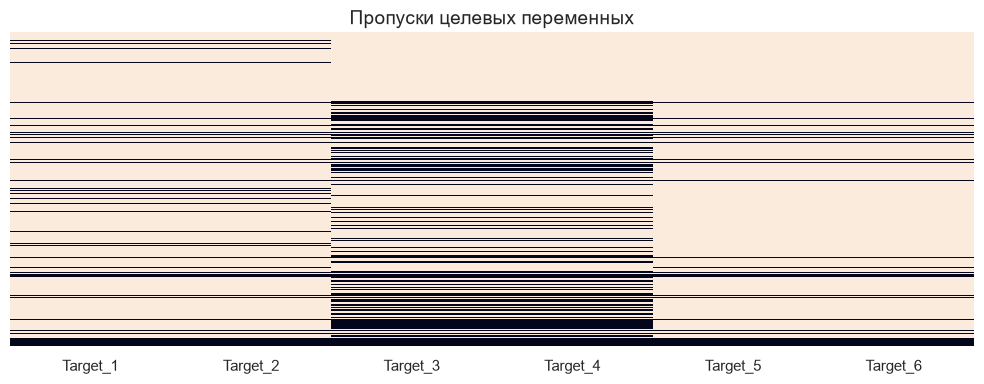

```python
plt.figure(figsize=(10, 4))
sns.heatmap(df[target_cols].isna(),
            cmap="rocket_r",
            cbar=False,
            yticklabels=False)
plt.title("Пропуски целевых переменных")
plt.tight_layout()
plt.show()
```

**ВЫВОДЫ по пропускам в данных:**

## Проверка нулей как скрытых пропусков

```
Проверка Target_3 и Target_4

Target_3
Количество нулей: 2318
Количество NaN : 3739
```

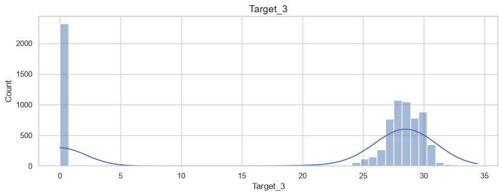

```
Target_4
Количество нулей: 2576
Количество NaN : 3740
```

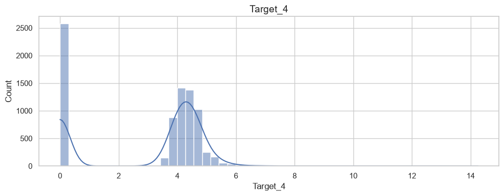

```python
print("\nПроверка Target_3 и Target_4")
for col in ["Target_3", "Target_4"]:
    zero_cnt = (df[col] == 0).sum()
    nan_cnt = df[col].isna().sum()
    print(f"\n{col}")
    print(f"Количество нулей: {zero_cnt}")
    print(f"Количество NaN : {nan_cnt}")
    plt.figure(figsize=(10,4))
    sns.histplot(df[col], bins=50, kde=True)
    plt.title(col)
    plt.tight_layout()
    plt.show()
```

**ВЫВОДЫ по проверке нулей как скрытых пропусков:**

Распределения `Target_3` и `Target_4` имеют резкую бимодальность: значительная доля наблюдений (2318 и 2576 соответственно) сосредоточена строго в нуле, а остальные данные формируют нормальное распределение с положительными модами (~28 и ~4.5), что указывает либо на реальное отсутствие показателя при определённых рецептурах (физический ноль), либо на скрытый пропуск измерений, и различие этих состояний критически важно, так как объединение нулей с **NaN** исказит физику процесса; учитывая, что суммарно неинформативных точек (**NaN** + явные нули) более 50%, стандартная регрессия неэффективна, поэтому рекомендуется провести анализ корреляции нулей с признаками и агрегатом, а для моделирования применить двухэтапный подход (классификация «ноль/не ноль» + регрессия для ненулевых) либо zero-inflated модели, чтобы обеспечить технологу честную оценку вероятности получения продукта с такими характеристиками.

.

## Анализ природы пропусков

```
================================================================================
ПРИРОДА ПРОПУСКОВ
================================================================================

------------------------------------------------------------
Target_1
------------------------------------------------------------

Доля пропусков по агрегатам
```

```
Aggregate
A_2   100.00000
A_8    43.28358
A_6    20.22631
A_5    18.25054
A_7    13.40726
A_3     6.70047
A_4     5.38980
A_1     2.83192
Name: Missing, dtype: float64
```

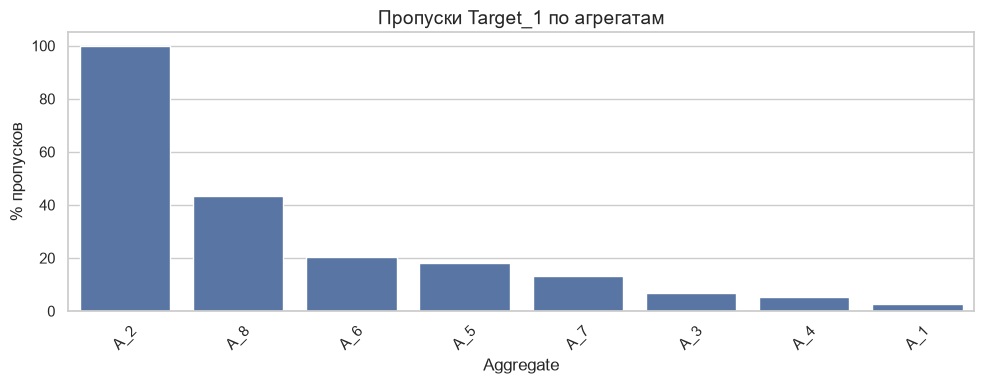

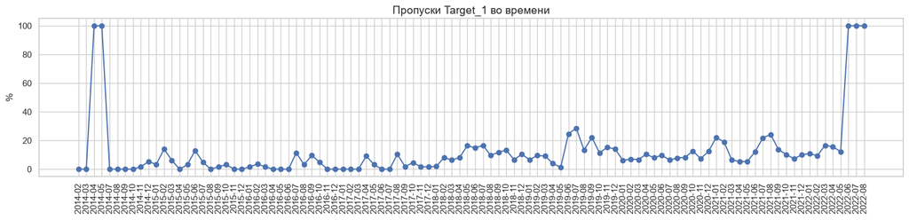

```
------------------------------------------------------------
Target_2
------------------------------------------------------------

Доля пропусков по агрегатам
```

```
Aggregate
A_2   100.00000
A_8    43.28358
A_6    20.22631
A_5    17.76458
A_7    11.99597
A_3     6.70047
A_4     5.38980
A_1     2.83192
Name: Missing, dtype: float64
```

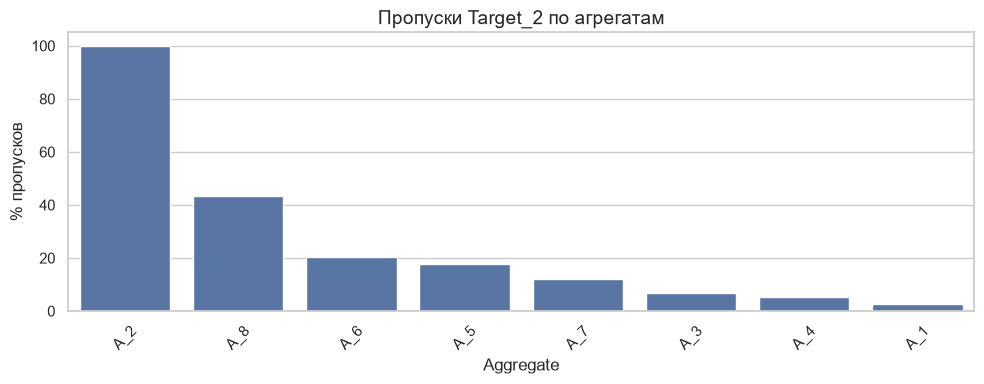

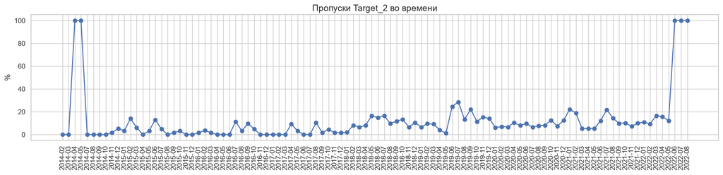

```
------------------------------------------------------------
Target_3
------------------------------------------------------------

Доля пропусков по агрегатам
```

```
Aggregate
A_8   60.94527
A_6   54.73833
A_5   47.35421
A_7   41.12903
A_4   34.79307
A_3   21.04310
A_1   18.97757
A_2    0.84746
Name: Missing, dtype: float64
```

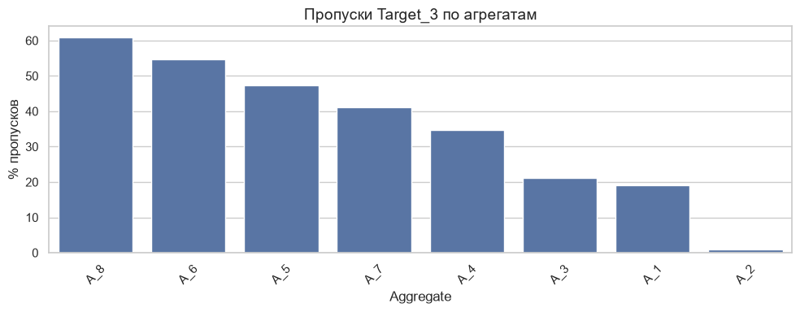

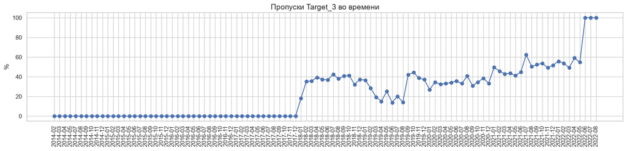

```
------------------------------------------------------------
Target_4
------------------------------------------------------------

Доля пропусков по агрегатам
```

```
Aggregate
A_8   60.94527
A_6   54.73833
A_5   47.35421
A_7   41.12903
A_4   34.79307
A_3   21.04310
A_1   19.01434
A_2    0.84746
Name: Missing, dtype: float64
```

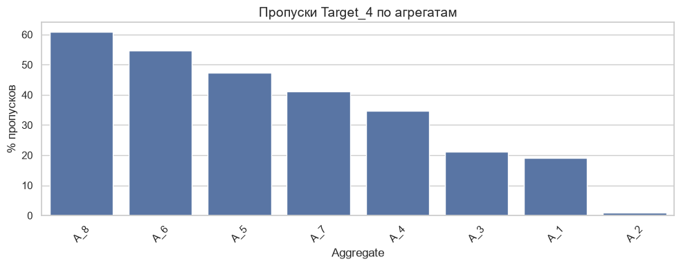

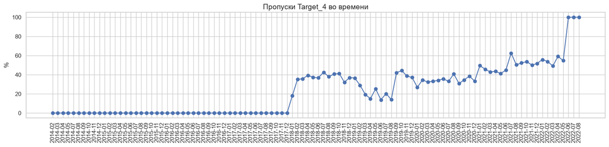

```
------------------------------------------------------------
Target_5
------------------------------------------------------------

Доля пропусков по агрегатам
```

```
Aggregate
A_8   43.28358
A_6   20.22631
A_5   13.44492
A_7    9.47581
A_3    6.91778
A_4    5.34167
A_1    2.83192
A_2    0.42373
Name: Missing, dtype: float64
```

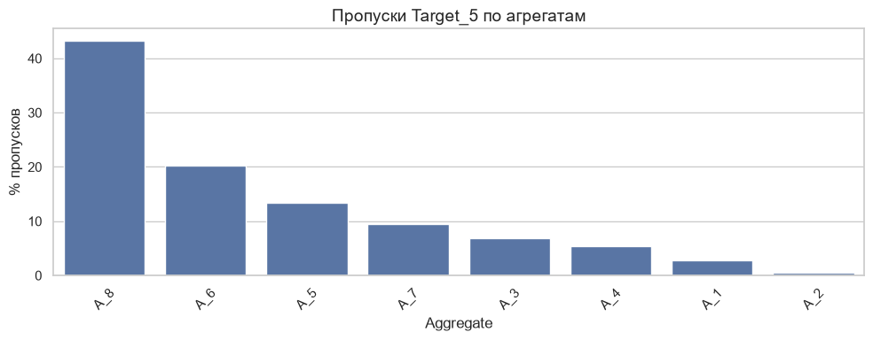

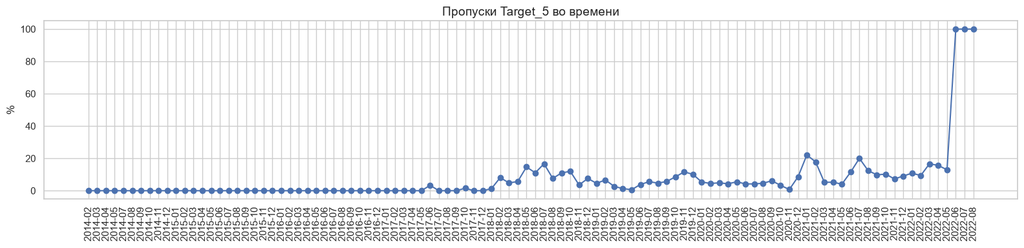

```
------------------------------------------------------------
Target_6
------------------------------------------------------------

Доля пропусков по агрегатам
```

```
Aggregate
A_8   43.28358
A_6   20.22631
A_5   13.44492
A_7    9.47581
A_3    6.80913
A_4    5.34167
A_1    2.83192
A_2    0.42373
Name: Missing, dtype: float64
```

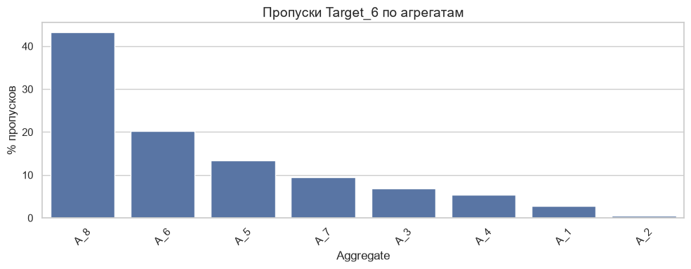

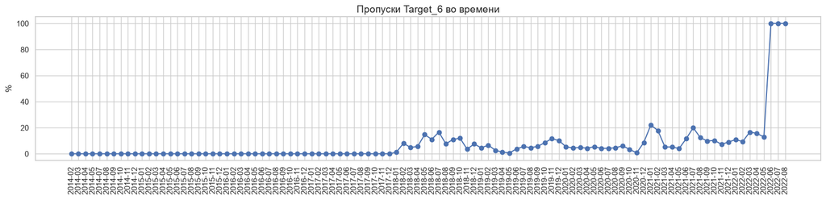

```python
print("\n" + "=" * 80)
print("ПРИРОДА ПРОПУСКОВ")
print("=" * 80)

for target in target_cols:
    print("\n" + "-" * 60)
    print(target)
    print("-" * 60)
    tmp = df.copy()
    tmp["Missing"] = tmp[target].isna()
    print("\nДоля пропусков по агрегатам")
    agg_table = (tmp.groupby("Aggregate")["Missing"].mean().sort_values(ascending=False)* 100)
    display(agg_table)
    plt.figure(figsize=(10,4))
    sns.barplot(x=agg_table.index, y=agg_table.values)
    plt.ylabel("% пропусков")
    plt.title(f"Пропуски {target} по агрегатам")
    plt.xticks(rotation=45)
    plt.tight_layout()
    plt.show()
    # по месяцам
    tmp["Month"] = tmp["DATE"].dt.to_period("M").astype(str)
    monthly = (tmp.groupby("Month")["Missing"].mean()*100)
    plt.figure(figsize=(16,4))
    plt.plot(monthly.index, monthly.values, marker="o")
    plt.xticks(rotation=90)
    plt.ylabel("%")
    plt.title(f"Пропуски {target} во времени")
    plt.tight_layout()
    plt.show()
```

**ВЫВОДЫ по анализу природы пропусков:**

Распределение пропусков для `Target_6` полностью повторяет паттерн `Target_5`: на агрегате `A_2` минимум пропусков (около 0.4%), на `A_8` – критический уровень (более 40%), а временная динамика идентична – стабильно низкий уровень до 2017 года, затем рост и скачок до 100% в июне–августе 2022, что подтверждает сопряжённость этих двух показателей, измеряемых синхронно на одних агрегатах и в одни периоды, что упрощает их обработку как единого блока. Суммируя по всем шести целевым переменным, выделяются три группы пропусков, диктующие архитектуру решения: первая (`Target_1`, `Target_2`) – недоступна на агрегате `A_2`, но надёжна на остальных; вторая (`Target_3`, `Target_4`) – структурные нули и массовые пропуски на большинстве агрегатов, требующие отдельной модели или двухэтапного подхода; третья (`Target_5`, `Target_6`) – исторически наиболее стабильна, но полностью отсутствует в периоде валидации (июнь–август 2022) из-за системного сбоя или остановки измерений.

Ключевой вывод: модель должна быть модульной – прогноз для каждого таргета или группы следует строить на своей релевантной подвыборке данных, исключая агрегаты и периоды, где измерения физически не проводились, чтобы избежать обучения на «шуме» пропусков и обеспечить честную оценку качества прогноза именно там, где это действительно нужно производству.

# Анализ целевых переменных

```
================================================================================
АНАЛИЗ TARGET
================================================================================
```

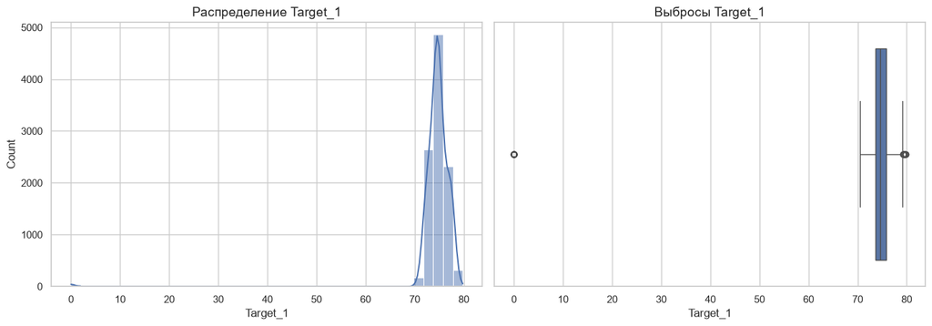

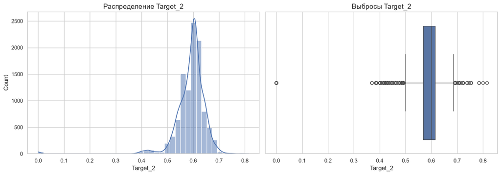

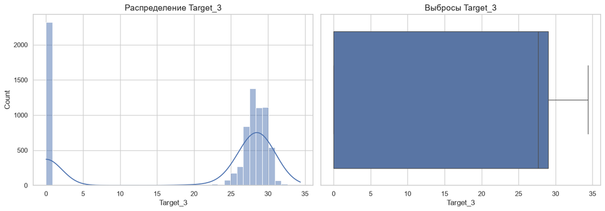

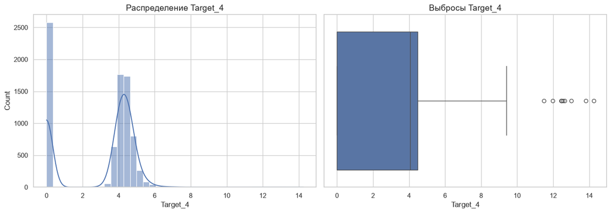

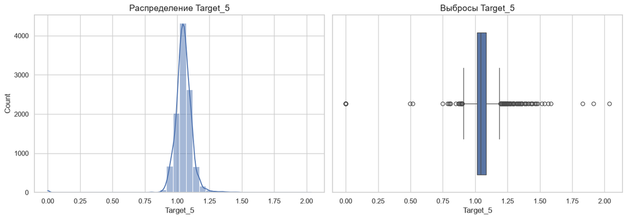

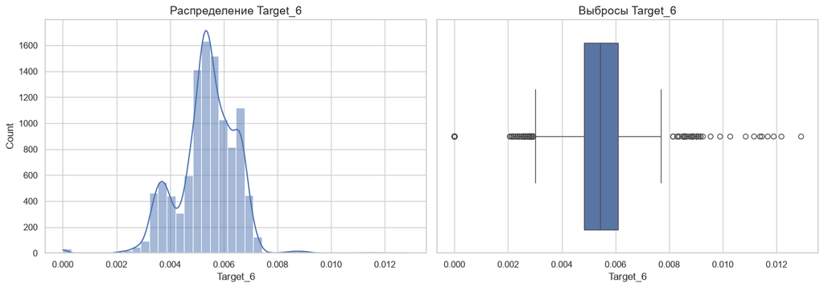

```python
print("\n" + "=" * 80)
print("АНАЛИЗ TARGET")
print("=" * 80)

for col in target_cols:
    fig, ax = plt.subplots(1,2, figsize=(14,5))
    sns.histplot(df[col], kde=True, bins=40, ax=ax[0])
    ax[0].set_title(f"Распределение {col}")
    sns.boxplot(x=df[col], ax=ax[1])
    ax[1].set_title(f"Выбросы {col}")
    plt.tight_layout()
    plt.show()
```

**ВЫВОДЫ по целевым переменным:**

## Корреляция Target

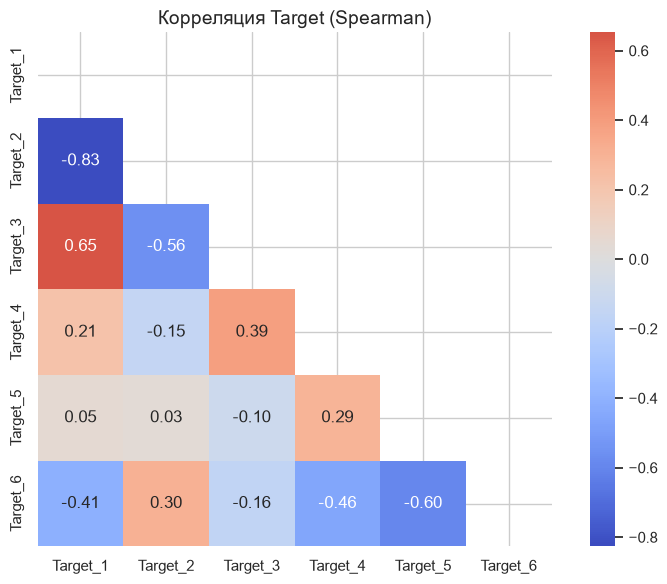

```python
target_corr = df[target_cols].corr(method="spearman")

# Создаем маску для верхней треугольной части (включая диагональ)
mask = np.triu(np.ones_like(target_corr, dtype=bool))
plt.figure(figsize=(8,6))
sns.heatmap(target_corr,
            annot=True,
            cmap="coolwarm",
            center=0,
            mask=mask,          # скрываем верхнюю часть
            square=True,        # делаем ячейки квадратными (опционально)
            fmt=".2f")          # формат чисел (опционально)
plt.title("Корреляция Target (Spearman)")
plt.tight_layout()
plt.show()
```

## Feature -> Target

```
================================================================================
КОРРЕЛЯЦИЯ FEATURE -> TARGET
================================================================================
```

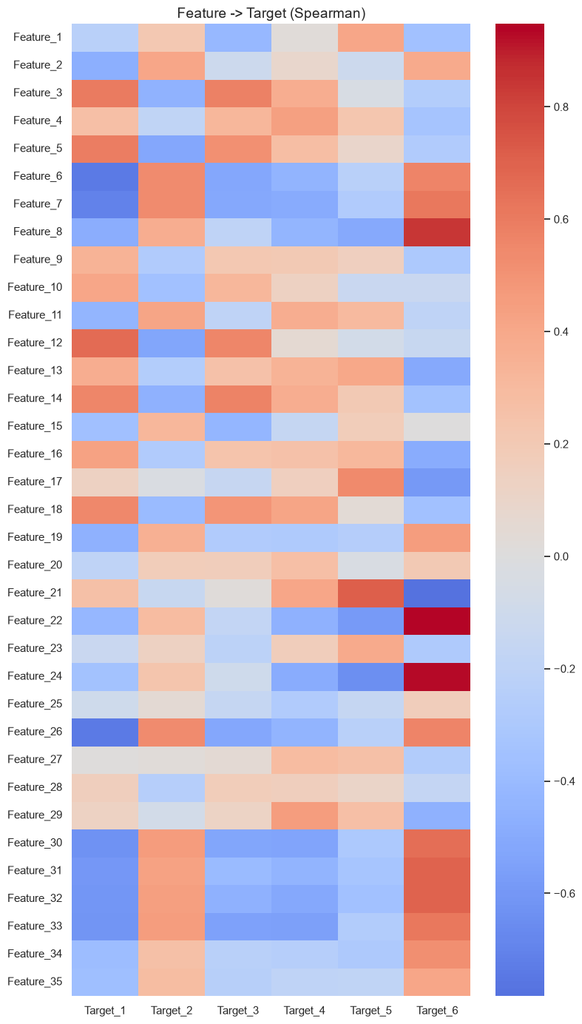

```python
print("\n" + "=" * 80)
print("КОРРЕЛЯЦИЯ FEATURE -> TARGET")
print("=" * 80)
corr_matrix = df[feature_cols + target_cols].corr(method="spearman")
feature_target_corr = corr_matrix.loc[feature_cols, target_cols]
plt.figure(figsize=(8,14))
sns.heatmap(feature_target_corr, cmap="coolwarm", center=0)
plt.title("Feature -> Target (Spearman)")
plt.tight_layout()
plt.show()
```

```python
important_features = {}
for target in target_cols:
    tmp = (feature_target_corr[target].abs().sort_values(ascending=False))
    important_features[target] = tmp.head(10)
    print("\n")
    print("="*60)
    print(target)
    print("="*60)
    display(tmp.head(10))
```

```
============================================================
Target_1
============================================================
```

```
Feature_26   0.74131
Feature_6    0.74131
Feature_7    0.70591
Feature_12   0.66717
Feature_30   0.63118
Feature_33   0.61865
Feature_32   0.61135
Feature_3    0.59789
Feature_31   0.59702
Feature_5    0.59017
Name: Target_1, dtype: float64
```

```
============================================================
Target_2
============================================================
```

```
Feature_26   0.54058
Feature_6    0.54057
Feature_7    0.53247
Feature_12   0.53083
Feature_5    0.51548
Feature_30   0.46578
Feature_14   0.46103
Feature_33   0.45978
Feature_3    0.45857
Feature_32   0.44400
Name: Target_2, dtype: float64
```

```
============================================================
Target_3
============================================================
```

```
Feature_3    0.57684
Feature_14   0.57411
Feature_12   0.55529
Feature_33   0.55113
Feature_30   0.52872
Feature_26   0.52459
Feature_6    0.52459
Feature_5    0.51466
Feature_7    0.50671
Feature_18   0.49265
Name: Target_3, dtype: float64
```

```
============================================================
Target_4
============================================================
```

```
Feature_33   0.55863
Feature_30   0.53789
Feature_32   0.50901
Feature_7    0.49352
Feature_24   0.48681
Feature_22   0.46425
Feature_29   0.45668
Feature_26   0.44979
Feature_6    0.44979
Feature_31   0.44665
Name: Target_4, dtype: float64
```

```
============================================================
Target_5
============================================================
```

```
Feature_21   0.71406
Feature_24   0.64646
Feature_22   0.58648
Feature_17   0.54285
Feature_8    0.50199
Feature_1    0.40939
Feature_13   0.40202
Feature_23   0.38842
Feature_32   0.35917
Feature_31   0.32883
Name: Target_5, dtype: float64
```

```
============================================================
Target_6
============================================================
```

```
Feature_22   0.94726
Feature_24   0.93216
Feature_8    0.84315
Feature_21   0.78302
Feature_32   0.69967
Feature_31   0.69710
Feature_30   0.65598
Feature_33   0.61808
Feature_7    0.61604
Feature_17   0.58832
Name: Target_6, dtype: float64
```

**ВЫВОДЫ по корреляционной структуры целевых переменных и признаков:**

Матрица корреляций Спирмена между таргетами выявляет сильную внутреннюю структуру данных, которая диктует стратегию моделирования. Наиболее значимая связь — сильная отрицательная корреляция (-0.83) между `Target_1` и `Target_2`, что указывает на их физическую или химическую взаимозависимость (например, комплементарные компоненты состава). Также заметна умеренная положительная связь `Target_1` с `Target_3` (0.65) и отрицательная `Target_5` с `Target_6` (-0.60). Для технолога это означает, что модель не должна рассматривать 6 таргетов как независимые задачи: прогнозирование одного показателя автоматически дает информацию о другом. Это открывает возможность использования многозадачного обучения (`Multi-output Regression`) или пост-процессинга прогнозов для обеспечения физической согласованности результатов.

## Мультиколлинеарность

```
================================================================================
МУЛЬТИКОЛЛИНЕАРНОСТЬ
================================================================================
```

|  | Feature_1 | Feature_2 | Correlation |
| --- | --- | --- | --- |
| 6 | Feature_6 | Feature_26 | 1.00000 |
| 13 | Feature_30 | Feature_33 | 0.98315 |
| 4 | Feature_22 | Feature_24 | 0.96310 |
| 15 | Feature_32 | Feature_33 | 0.93379 |
| 11 | Feature_30 | Feature_32 | 0.93274 |
| 12 | Feature_31 | Feature_32 | 0.92721 |
| 10 | Feature_30 | Feature_31 | 0.91936 |
| 9 | Feature_25 | Feature_27 | 0.91517 |
| 14 | Feature_31 | Feature_33 | 0.91164 |
| 7 | Feature_7 | Feature_26 | 0.88821 |
| 0 | Feature_6 | Feature_7 | 0.88821 |
| 5 | Feature_4 | Feature_25 | 0.88388 |
| 8 | Feature_4 | Feature_27 | 0.88152 |
| 2 | Feature_8 | Feature_24 | 0.87094 |
| 1 | Feature_8 | Feature_22 | 0.86770 |
| 3 | Feature_21 | Feature_24 | 0.85809 |

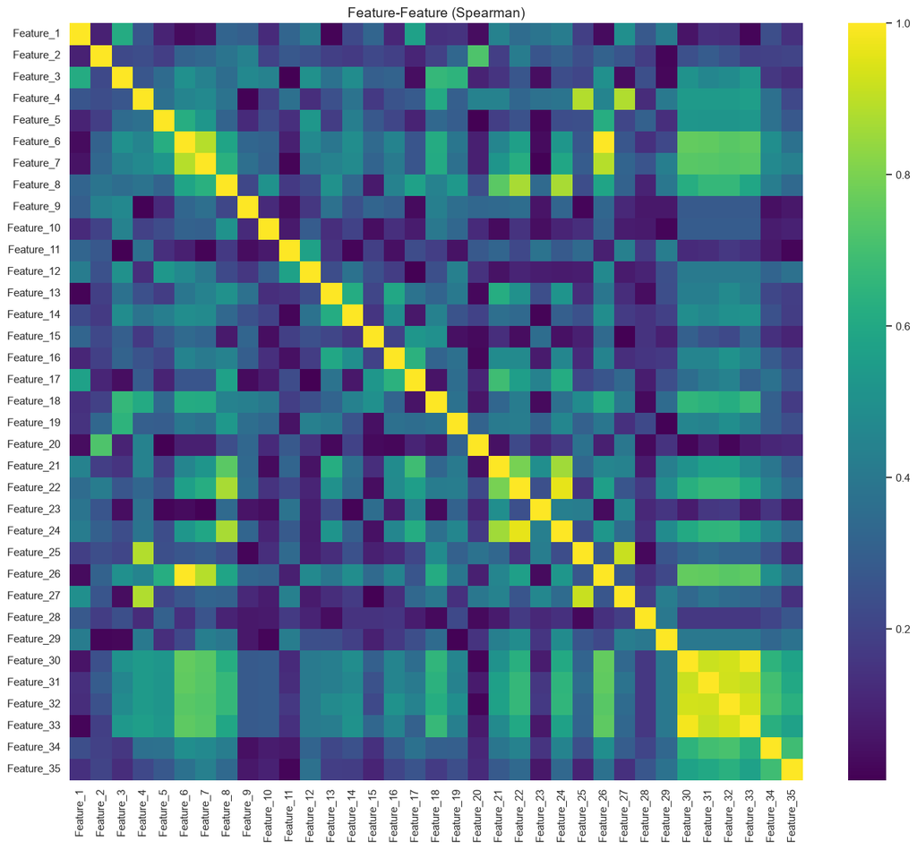

```python
print("\n" + "=" * 80)
print("МУЛЬТИКОЛЛИНЕАРНОСТЬ")
print("=" * 80)
feature_corr = df[feature_cols].corr(method="spearman").abs()
upper = feature_corr.where(np.triu(np.ones(feature_corr.shape), k=1).astype(bool))
multicollinear_pairs = []
for col in upper.columns:
    high_corr = upper[col][upper[col] > 0.85]
    for idx, value in high_corr.items():
        multicollinear_pairs.append((idx, col, value))
multicollinear_df = pd.DataFrame(multicollinear_pairs, columns=["Feature_1", "Feature_2", "Correlation"])
display(multicollinear_df.sort_values("Correlation", ascending=False))
plt.figure(figsize=(14,12))
sns.heatmap(feature_corr,
            cmap="viridis",
            cbar=True)
plt.title("Feature-Feature (Spearman)")
plt.tight_layout()
plt.show()
```

**ВЫВОДЫ по корреляционной структуры целевых переменных и признаков:**

Анализ матрицы корреляций выявил критическую мультиколлинеарность: пары с корреляцией 1.0 (`Feature_6` и `Feature_26`) и группа {`Feature_30–Feature_33`} с коэффициентами >0.9, что указывает на дублирование измерений или физико-химические соотношения; для чувствительных к коллинеарности моделей (линейная регрессия) это приведёт к неустойчивости коэффициентов, тогда как для градиентного бустинга проблема менее значима. Для бизнес-задачи высокая корреляция позволяет упростить модель без потери качества — рекомендуется кластеризовать признаки и оставить по одному представителю из каждой группы (например, из `F30–F33` выбрать наиболее технологически понятный), что снизит шум, ускорит обучение и улучшит интерпретируемость `feature importance`, при этом драйверы разных таргетов обычно попадают в разные кластеры, подтверждая их независимое влияние на качество продукции.

# Zero inflation (избыток нулей / раздувание нулей)

Наличие в датасете признаков, в которых слишком много нулевых значений

```
================================================================================
ZERO INFLATION
================================================================================
```

```
Feature_28   0.96348
Feature_9    0.89521
Feature_10   0.89001
Feature_29   0.80812
Feature_12   0.80301
Feature_30   0.57070
Feature_31   0.57070
Feature_32   0.57070
Feature_33   0.57070
dtype: float64
```

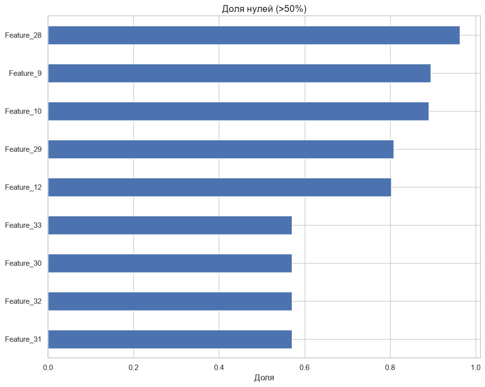

```python
print("\n" + "=" * 80)
print("ZERO INFLATION")
print("=" * 80)
zero_share = (df[feature_cols] == 0).mean()
zero_features = zero_share[zero_share > 0.5].sort_values(ascending=False)
display(zero_features)
plt.figure(figsize=(10,8))
zero_features.sort_values().plot(kind="barh")
plt.title("Доля нулей (>50%)")
plt.xlabel("Доля")
plt.tight_layout()
plt.show()
```

**ВЫВОДЫ по zero-inflation признаков:**

Анализ доли нулевых значений выявил критическую разреженность: пять признаков (`Feature_28`, `Feature_9`, `Feature_10`, `Feature_29`, `Feature_12`) содержат более **80%** нулей, а `Feature_28` — **96.3%**, что указывает на редкие добавки или специфические режимы и создаёт риск переобучения на шум; при этом группа {`Feature_30`–`Feature_33`} имеет ровно **57.07%** нулей, что вместе с их высокой взаимной корреляцией (**>0.9**) подтверждает их природу как одного компонента или стехиометрически связанных веществ. Для технолога важно, что высокая важность одного из этих признаков в модели означает значимость всей группы, поэтому рекомендуется либо объединить их (через **PCA** или суммирование), либо оставить только один представитель, чтобы избежать искусственного завышения веса данной группы в прогнозе качества продукции.

# Анализ выбросов

```python
print("\n" + "=" * 80)
print("ВЫБРОСЫ")
print("=" * 80)
outlier_features = []
for col in feature_cols:
    q1 = df[col].quantile(0.25)
    q3 = df[col].quantile(0.75)
    iqr = q3 - q1
    lower = q1 - 1.5 * iqr
    upper_b = q3 + 1.5 * iqr
    outliers = ((df[col] < lower) | (df[col] > upper_b)).sum()
    if outliers > 0:
        outlier_features.append({
            "Feature": col,
            "Outliers": outliers,
            "Percent": outliers / len(df) * 100})
outlier_df = (pd.DataFrame(outlier_features).sort_values("Percent", ascending=False))
display(outlier_df)
```

```
================================================================================
ВЫБРОСЫ
================================================================================
```

|  | Feature | Outliers | Percent |
| --- | --- | --- | --- |
| 10 | Feature_12 | 2314 | 19.69865 |
| 27 | Feature_29 | 2254 | 19.18788 |
| 9 | Feature_10 | 1292 | 10.99855 |
| 8 | Feature_9 | 1231 | 10.47927 |
| 29 | Feature_31 | 1171 | 9.96850 |
| 28 | Feature_30 | 1159 | 9.86635 |
| 13 | Feature_15 | 811 | 6.90389 |
| 23 | Feature_25 | 688 | 5.85681 |
| 0 | Feature_1 | 571 | 4.86082 |
| 19 | Feature_21 | 505 | 4.29897 |
| 26 | Feature_28 | 429 | 3.65200 |
| 21 | Feature_23 | 412 | 3.50728 |
| 4 | Feature_5 | 409 | 3.48174 |
| 3 | Feature_4 | 398 | 3.38810 |
| 18 | Feature_20 | 364 | 3.09866 |
| 25 | Feature_27 | 350 | 2.97948 |
| 31 | Feature_34 | 331 | 2.81774 |
| 30 | Feature_33 | 302 | 2.57087 |
| 16 | Feature_18 | 263 | 2.23887 |
| 17 | Feature_19 | 260 | 2.21333 |
| 6 | Feature_7 | 257 | 2.18779 |
| 24 | Feature_26 | 242 | 2.06010 |
| 5 | Feature_6 | 241 | 2.05159 |
| 1 | Feature_2 | 214 | 1.82174 |
| 20 | Feature_22 | 204 | 1.73661 |
| 11 | Feature_13 | 184 | 1.56636 |
| 15 | Feature_17 | 161 | 1.37056 |
| 14 | Feature_16 | 128 | 1.08964 |
| 12 | Feature_14 | 123 | 1.04708 |
| 32 | Feature_35 | 118 | 1.00451 |
| 2 | Feature_3 | 95 | 0.80872 |
| 22 | Feature_24 | 57 | 0.48523 |
| 7 | Feature_8 | 42 | 0.35754 |

**ВЫВОДЫ по выбросам:**

# Контрольные карты (Control Charts)

```
================================================================================
CONTROL CHARTS
================================================================================
```

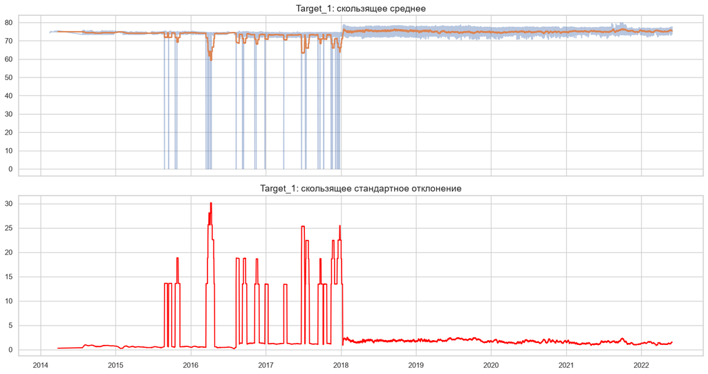

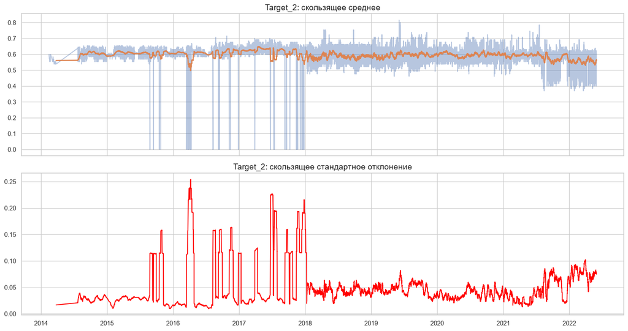

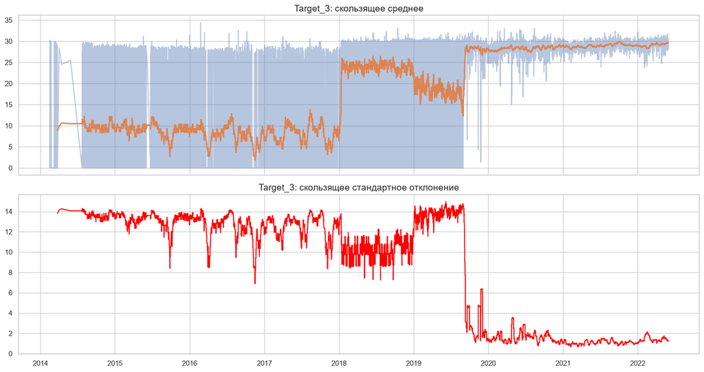

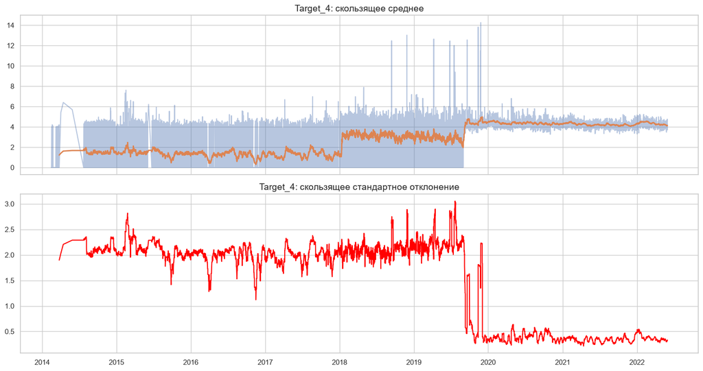

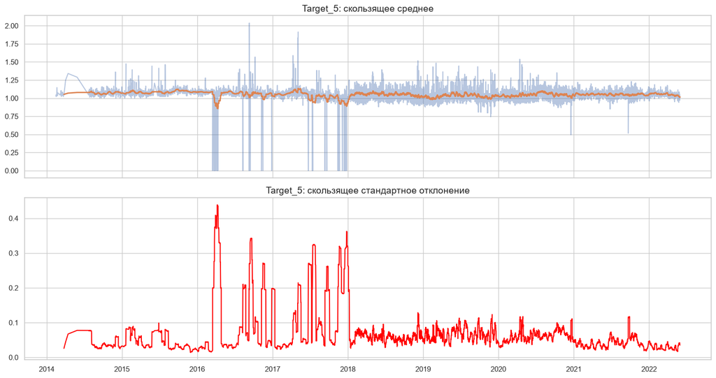

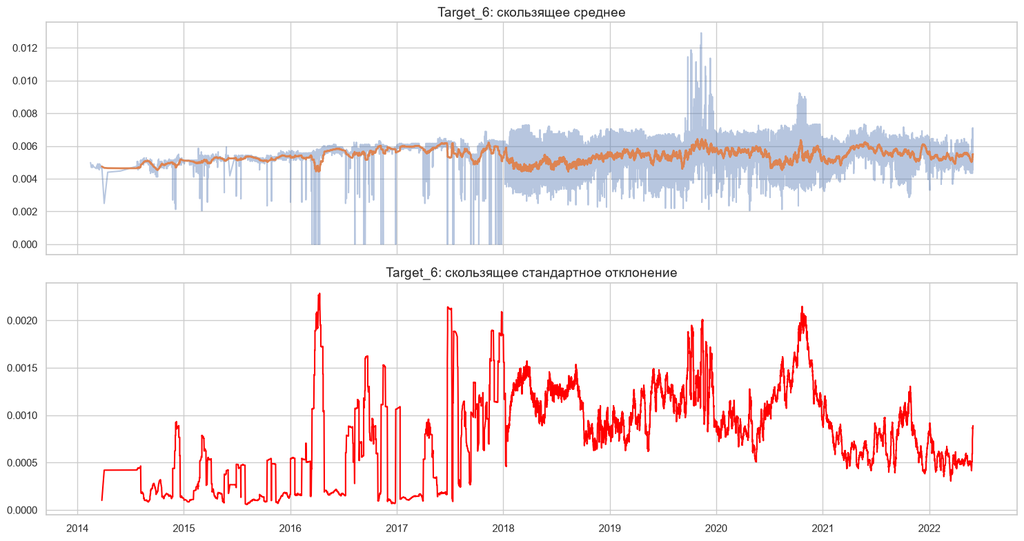

```python
print("\n" + "=" * 80)
print("CONTROL CHARTS")
print("=" * 80)

WINDOW = 30

for target in target_cols:
    tmp = (df[["DATE", target]].dropna().sort_values("DATE"))
    rolling_mean = (tmp[target].rolling(WINDOW).mean())
    rolling_std = (tmp[target].rolling(WINDOW).std())
    fig, ax = plt.subplots(2,1, figsize=(15,8), sharex=True)
    ax[0].plot(tmp["DATE"], tmp[target],alpha=0.4)
    ax[0].plot(tmp["DATE"], rolling_mean, linewidth=2)
    ax[0].set_title(f"{target}: скользящее среднее")
    ax[1].plot(tmp["DATE"], rolling_std, color="red")
    ax[1].set_title(f"{target}: скользящее стандартное отклонение")
    plt.tight_layout()
    plt.show()
```

**ВЫВОДЫ по контрольным картам:**